# Chapter 10 Review; Chapter 11: Capital Budgeting

FINA 3000 · Business Finance I · Class 20

Dr. Justin Mohr

October 29, 2026

## Component Costs

$$WACC = w_d r_d \left( 1 - T \right) + w_p r_p + w_c r_s$$

- The w’s refer to the weight (or%) of each type of capital in the firm’s capital structure.
- The r’s refer to the cost of each component.
- rd=Required Rate of Return on debt
- rp=Required Rate of Return on preferred stock
- rs=Required Rate of Return on common stock

## 🍬 Candy Question

Why does the cost of debt get multiplied by $(1 - T)$ but preferred and common stock do not?

## Determine Costs and Weights

$WACC = w_d r_d \left( 1 - T \right) + w_p r_p + w_c r_s$

Determine Costs using our prior methods

Use target capital structure, not current capital structure to determine weights (w, % of the firm financed with each source)

## 🍬 Candy Question

To find the weights, do we use the firm’s current capital structure or its target capital structure?

## Prior Formulas

$r_d$ = Required Rate of Return on debt = r* + IP + DRP + LP + MRP = Yield to Maturity

$r_p$ = Required Rate of Return on preferred stock = $\frac{Dividend}{Stock\ Price}$

$r_s$ = Required Rate of Return on common stock = $r_s = r_{RF} + \left( r_M - r_{RF} \right) \beta$

- r* = real risk-free rate of interest
- IP = inflation premium
- DRP = default risk premium
- LP = liquidity premium
- MRP = maturity risk premium
- $r_{RF}$ = Risk Free Rate
- $r_M$ = Return on the market
- $\beta_i$ = Beta of stock i
- $r_M - r_{RF}$ = Market Risk Premium

## 3 ways to determine cost of retained earnings

Three routes to the cost of retained earnings

| Methodology | Formula |
| --- | --- |
| CAPM (capital asset pricing model) | r<sub>s</sub> = r<sub>RF</sub> + (r<sub>M</sub> – r<sub>RF</sub>) β |
| DDM | r<sub>s</sub> = (D<sub>1</sub>/P<sub>0</sub>) + g |
| Before tax bond Yield Plus Risk Premium | r<sub>s</sub> = r<sub>d</sub> + RP* |

* Not the same as the CAPM Risk Premium

## 🍬 Candy Question

The Haunted Hayride just paid a $1.50 dividend. Dividends grow 4% a year and the stock sells for $26. What is its DCF cost of equity?

## 🍬 Candy Question

The Haunted Hayride has a beta of 1.25. The risk-free rate is 4% and the market risk premium is 6%. What is its CAPM cost of equity?

## WACC

Balance sheet

| 2021 |  |
| --- | --- |
| Current assets | $ 2,000.00 |
| Net fixed assets | $ 3,000.00 |
| Total assets | $ 5,000.00 |
| AP&Accruals | $ 900.00 |
| STR debt | $ 100.00 |
| LTR debt | $ 1,100.00 |
| Preferred Stock (10K shares) | $ 250.00 |
| Common Stock (50K shares) | $ 1,300.00 |
| Retained Earnings | $ 1,350.00 |
| Total common equity | $ 2,650.00 |
| Total liabilities and equity | $ 5,000.00 |

- Before tax cost of debt: 10%
- Preferred Dividend $3.30
- Last YR dividend: $2.10
- Marginal tax rate: 25%
- Preferred Stock Price $30
- Common Stock Price: $55
- Beta: 1.516
- Floatation Cost: 10%
- Expected Common Dividend Growth: 9%
- Risk-free: 6%
- Market Risk Premiumn: 5%
- What is the after-tax cost of debt?
- Cost of preferred stock?
- DCF cost of Equity from RE?
- DCF cost of new common stock?

## WACC

Balance sheet

| 2021 |  |
| --- | --- |
| Current assets | $ 2,000.00 |
| Net fixed assets | $ 3,000.00 |
| Total assets | $ 5,000.00 |
| AP&Accruals | $ 900.00 |
| STR debt | $ 100.00 |
| LTR debt | $ 1,100.00 |
| Preferred Stock (10K shares) | $ 250.00 |
| Common Stock (50K shares) | $ 1,300.00 |
| Retained Earnings | $ 1,350.00 |
| Total common equity | $ 2,650.00 |
| Total liabilities and equity | $ 5,000.00 |

- Before tax cost of debt: 10%
- Preferred Dividend $3.30
- Last YR dividend: $2.10
- Marginal tax rate: 25%
- Preferred Stock Price $30
- Common Stock Price: $55
- Beta: 1.516
- Floatation Cost: 10%
- Expected Common Dividend Growth: 9%
- Risk-free: 6%
- Market Risk Premiumn: 5%
- CAPM cost of Equity from RE?
- CAPM cost of new common stock?

## WACC

Balance sheet

| 2021 |  |
| --- | --- |
| Current assets | $ 2,000.00 |
| Net fixed assets | $ 3,000.00 |
| Total assets | $ 5,000.00 |
| AP&Accruals | $ 900.00 |
| STR debt | $ 100.00 |
| LTR debt | $ 1,100.00 |
| Preferred Stock (10K shares) | $ 250.00 |
| Common Stock (50K shares) | $ 1,300.00 |
| Retained Earnings | $ 1,350.00 |
| Total common equity | $ 2,650.00 |
| Total liabilities and equity | $ 5,000.00 |

- Before tax cost of debt: 10%
- Preferred Dividend $3.30
- Last YR dividend: $2.10
- Marginal tax rate: 25%
- Preferred Stock Price $30
- Common Stock Price: $55
- Cost of New Equity DCF: 0.136
- Cost of New Equity CAPM: 0.140
- Cost of Equity RE CAPM: 0.136
- After Tax Cost of debt: 0.075
- Cost of Preferred: 0.11
- Cost of Equity RE DCF: 0.132
- What is the WACC if they only use RE?
- If they have to issue new stock?

## 🍬 Candy Question

A costume shop is financed 40% with debt and 60% with common equity. Its before-tax cost of debt is 8%, its tax rate is 25% and its cost of equity is 12%. What is its WACC?

# Chapter 11

Mohr

## Capital Budgeting and its Measurements

- Net Present Value (NPV)
- Internal Rate of Return (IRR)
- Modified Internal Rate of Return (MIRR)
- Payback Methods: Regular vs. Discounted
- Multiple IRRs

## Why do we care?

Analysis of potential additions to fixed assets.

Long-term decisions; involve large expenditures and investments.

Very important to a firm’s future.

Capital budgeting is to a company what buying stocks and bonds are to an individual or institutional investor

## The Steps

Estimate cash flows (CFs) (inflows & outflows).

Assess riskiness of CFs.

Determine the appropriate cost of capital (use formula for WACC).

Find NPV and/or IRR.

Accept if NPV > 0 and/or IRR > WACC.

## Net Present Value

- Net Present Value measures the increase/decrease in shareholder wealth due to a company undertaking a capital project
- Typically, CF0 is an immediate cash outflow and the remaining cash flows are cash inflows

$$NPV = CF_0 + \frac{CF_1}{\left( 1 + WACC \right)^1} + \frac{CF_2}{\left( 1 + WACC \right)^2} ................................................$$

- WACC=discount rate=cost of capital
- CFt=Cash Flow in Year t
- t=year

## Two year lease

Justin’s Cupcakes is opening up a new storefront. It will cost 20K now and then there will be expected revenues of 11K the first year and 12K the second year. Justin’s WACC is 10 percent. What is the NPV?

## Do we want to do this?

## 🍬 Candy Question

A haunted house costs $10,000 to build and brings in $6,000 in each of the next 2 years. The WACC is 8%. What is the NPV? Do we build it?

## Do we like doing that by hand?

[figure not shown]

- No!
- So let us use the calculator
- CF worksheet, be sure to clear!
- Cfo is the initial CF
- C01 is the first CF
- F01 is how often that repeats (TRICKY)
- C0# is the number of the CF
- F0# is the frequency of that CF

## Resolving our problem

- Justin’s Cupcakes is opening up a new storefront. It will cost 20K now and then there will be expected revenues of 11K the first year and 12K the second year. Justin’s WACC is 10 percent. What is the NPV?
- CF worksheet and clear
- Cfo is -20,000, C01 is 11,000, leave F01, C02 is 12,000
- Then go to NPV, set I=10, then down to NPV, hit CPT

## Another practice question

Find the NPV of these CF

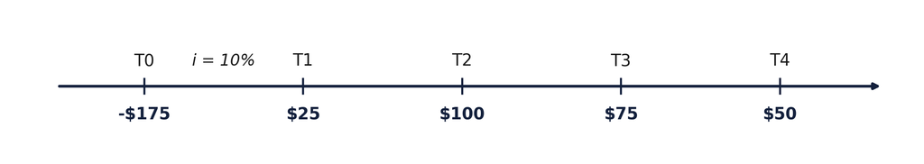

Link for video and good write up with this example: [Schweser Library](https://www.schweser.com/cfa/blog/how-to-pass-the-cfa-exam/ti-baii-plus-calculator-advanced-functions-for-the-cfa-exam)

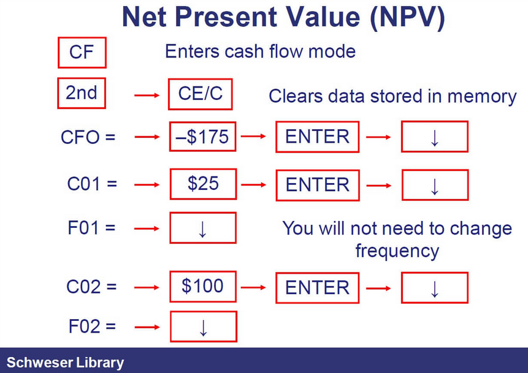

[figure not shown]

## Don’t touch the calculators yet!

- Lets introduce IRR
- NPV is very nice
  - Simple clean
  - Dollars added to shareholder wealth
- But what is the actual rate we need to be above?
  - Last problem was positive at 10%
  - Would it be positive at 13%?
  - What about 14? 15? 16?

## IRR

- Hit IRR and the CPT
- This is the internal rate of return, or the discount rate that sets the PV of the cash flows equal to zero
- Go check!

## Interpreting the IRR

- If IRR > WACC, you can conclude that present value of a project’s cash inflows exceeds the present value of its outflows.
- If IRR > WACC, accept project.
- If IRR < WACC, reject project.

## 🍬 Candy Question

A pumpkin patch costs $50,000 today and brings in $15,000 a year for 4 years. The WACC is 9%. What is the NPV? What do you enter for F01?

## 🍬 Candy Question

What is the pumpkin patch’s IRR? Should we take it at a 9% WACC?

## Cupcake Expansion

- Taylor’s Cupcakes is planning an expansion.
- Initial cost for new food trailer- $7000

Taylor’s Cupcakes expansion cash flows by year

| Year 1 - $3000 | Year 2 - $5000 | Year 3 - $5000 |
| --- | --- | --- |
| Year 4 - $5000 | Year 5 - $5000 | Year 6 - $4000 |

- Find the NPV if her discount rate is 10 percent. Then find the IRR

## Cupcake Expansion

Would the NPV positive with a rate of 58%?

## Excel also hates you (This will be a test question)

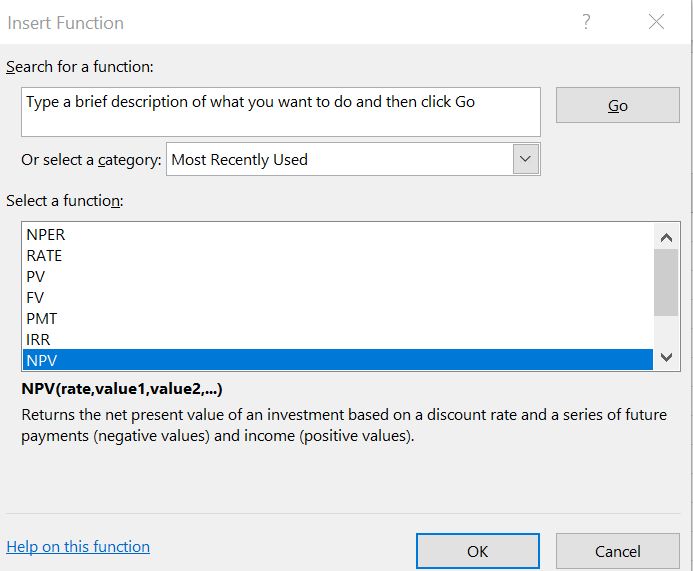

## 🍬 Candy Question

In Excel, Ivy types `=NPV(10%, -175, 25, 100, 75, 50)` for the T0 to T4 cash flows from earlier. She gets $18.97, not $20.87. What went wrong?

## Normal vs Nonnormal CF

Normal cash flows: Cost (negative CF) followed by a series of positive cash inflows. One change of signs.

Non-normal cash flows: Two or more changes of signs.

Most common non-normal: Cost (negative CF), then string of positive CFs, then cost to close project. Examples include nuclear power plant, strip mine, etc.

## 🍬 Candy Question

Which of these cash flow streams are non-normal?

- A: $-$, $+$, $+$, $+$
- B: $-$, $+$, $+$, $-$
- C: $-$, $-$, $+$, $+$

## Nonnormal: BAD

- Cfo:-1.6 C01: 10 C02: -10
- Find the IRR for me

Go to the NPV worksheet for me

What is the NPV if we have I=400

## Non-Normal

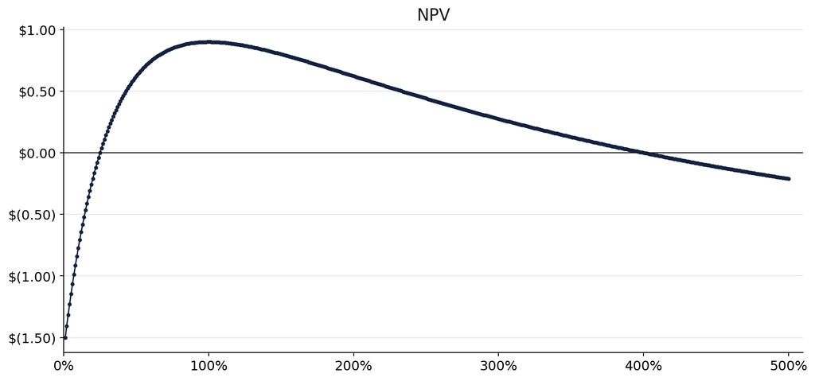

## Project types

Independent projects: If the cash flows of one are unaffected by the acceptance of the other.

Mutually exclusive projects: If the cash flows of one can be adversely impacted by the acceptance of the other.

- NPV=PV of inflows - PV of outflows=Net gain in wealth
  - If projects are independent, accept if the project NPV > 0.
  - If projects are mutually exclusive, accept project with the highest positive NPV, one that adds the most shareholder value.
- IRR
  - If projects are independent, accept all projects if IRR > WACC
  - If projects are mutually exclusive, accept project with higher IRR

## Conflicts between NPV and IRR

- Two mutually exclusive investment opportunities:
  - #1) Invest $1 now and receive $2 one year from now.
  - #2) Invest $100 now and receive $150 one year from now.
- WACC or cost of capital is 10%

The two rules disagree: #1 wins on IRR, #2 wins on NPV

[output not shown]

## IRR and NPV Conflicts

NPV is a better measure of shareholder wealth creation, but IRR is easier to understand

With mutually exclusive projects, accept one with higher NPV vs with one with higher IRR

If projects are independent, accept all where IRR>WACC

## 🍬 Candy Question

Project Ghost has an NPV of $500 and an IRR of 30%. Project Ghoul has an NPV of $900 and an IRR of 18%. The WACC is 10%. They are mutually exclusive. Which do we take? What if they were independent?

## Upcoming Dates

Upcoming class dates and deadlines

| Date | Topic | Due / Notes |
| --- | --- | --- |
| Sun Nov 1 | MindTap Ch 10 | HW DUE |
| Tue Nov 3 | Chapter 11: Capital Budgeting | - |
| Thu Nov 5 | Chapter 12: Cash Flow Estimation | - |
| Sun Nov 8 | MindTap Ch 11 | HW DUE |

**Office:** 325 Holman Hall · **Office hours:** T TH 10:50A-12:20P · jjmohr1@olemiss.edu